# Assignment3

## Map 2: How many parks are there in each NYC neighborhood?

Here was my first attempt at answering this question. I don’t think this is a good map - the fact that some neighborhooods in Queens and Brooklyn have more than 600 parks skews the data and makes it seem as if most of NYC has almost no parks because the first tier of my scale covers 0-200.

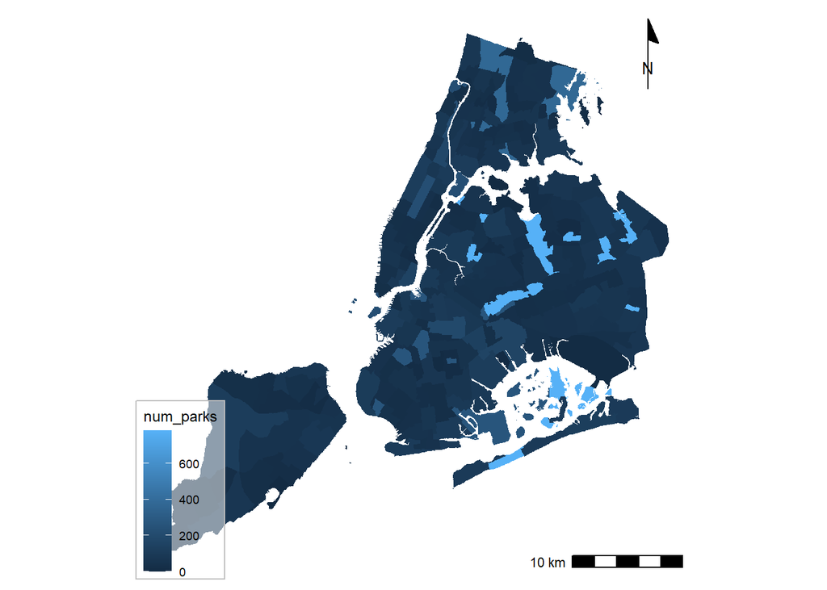

```r
nhoods <- nhoods %>%
  mutate(num_parks = lengths(st_covers(nhoods, parks)))

ggplot(nhoods) +
  geom_sf(color = NA,
          aes(fill = num_parks)) +
  scale_color_viridis_c(name = "NYC neighborhoods\nby number of parks",
                       breaks = breaks <- seq(0, 800, by = 100),
                       labels = paste(prettyNum(breaks, big.mark = ","),
                                      "parks")) +
  annotation_scale(location = "br") +
  annotation_north_arrow(location = "tr",
                         style = north_arrow_minimal()) +
theme_map() +
  theme(legend.background = element_rect(fill = alpha("white", 0.5),
                                         color = "gray")) +
  theme(legend.title = element_text("Number of Parks"))
```

I tried again - this time treating parks and neighborhoods as overlapping polygons.

```r
nhoods <- nhoods %>%
  mutate(num_parks = lengths(st_overlaps(nhoods, parks))) %>%
  mutate(has_parks = num_parks > 0)
```

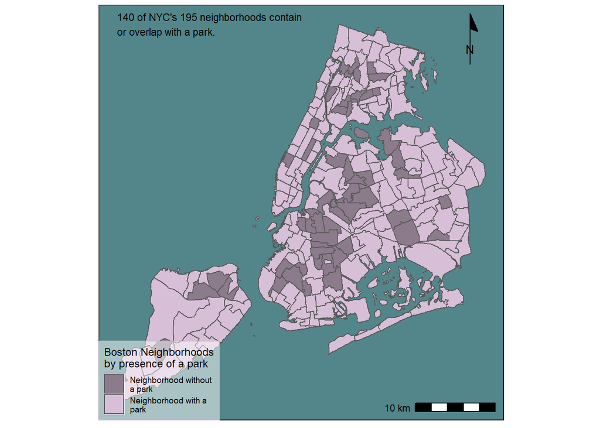

```r
n_parks_nhoods <- sum(nhoods$has_parks)

#This returns 140. 140 of NYC's neighborhoods have parks (as defined by the NYC Open Data parks dataset.)

left_side  <- st_bbox(parks)$xmin
top_side <- st_bbox(parks)$ymax

ggplot(parks) +
  geom_sf(fill = "darkgreen", color = NA) +
  geom_sf(data = nhoods,
          aes(fill = has_parks)) +
  scale_fill_manual(values = c("thistle4", "thistle"),
          name = "Boston Neighborhoods\nby presence of a park",
          labels = c("Neighborhood without\na park",
                     "Neighborhood with a\npark")) +
  annotation_scale(location = "br") +
  annotation_north_arrow(location = "tr",
                         style = north_arrow_minimal()) +
  annotate(geom = "text", x = left_side,
           y = top_side - 1000,
           label = paste(n_parks_nhoods ,
                         "of NYC's",
                         length(nhoods$Name),
                         "neighborhoods contain\nor overlap with",
                         "a park."),
           hjust = 0, vjust = 0, size = 3) +
  theme_map() +
  theme(panel.background = element_rect(fill = "cadetblue4"),
        legend.background = element_rect(fill = alpha("white", 0.5),
                                         color = "gray"))
```

## Map 3: How many points of interest are there in each NYC neighborhood?

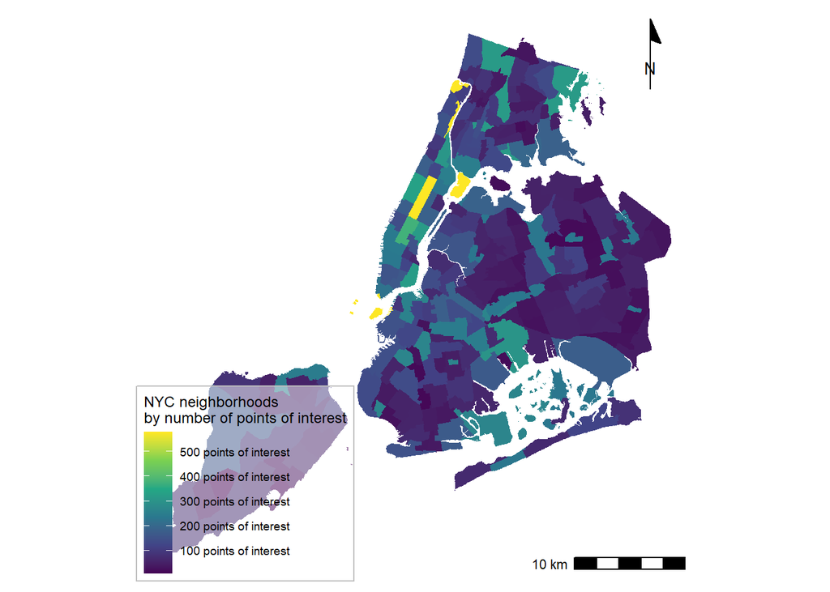

```r
nhoods <- nhoods %>%
  mutate(num_poi = lengths(st_covers(nhoods, poi)))

ggplot(nhoods) +
  geom_sf(color = NA,
          aes(fill = num_poi)) +
  scale_fill_viridis_c(name = "NYC neighborhoods\nby number of points of interest",
                       breaks = breaks <- seq(0, 600, by = 100),
                       labels = paste(prettyNum(breaks, big.mark = ","),
                                      "points of interest")) +
  annotation_scale(location = "br") +
  annotation_north_arrow(location = "tr",
                         style = north_arrow_minimal()) +
theme_map() +
  theme(legend.background = element_rect(fill = alpha("white", 0.5),
                                         color = "gray"))
```

## Map 4: What is the average density of subway entrances in each neighborhood?

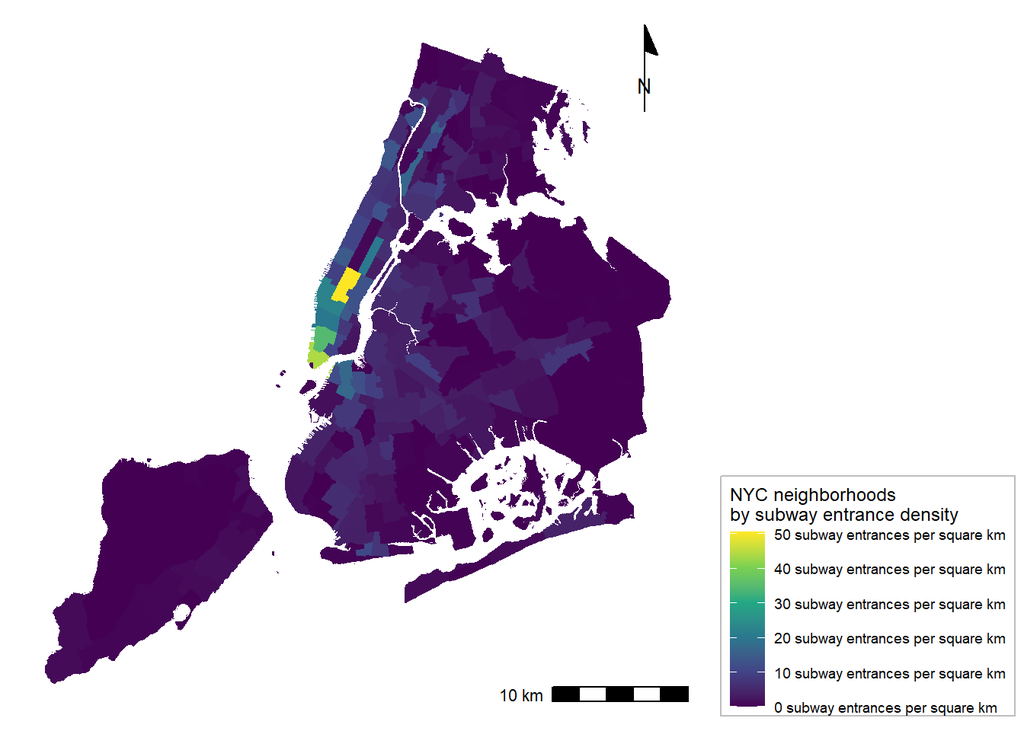

```r
nhoods <- nhoods %>%
  mutate(num_subway = lengths(st_covers(nhoods, subway)))

nhoods <- nhoods %>%
  mutate(area = set_units(st_area(nhoods), km^2)) %>%
  mutate(subway_dens = as.numeric(num_subway / area))

ggplot(nhoods) +
  geom_sf(color = NA,
          aes(fill = subway_dens)) +
    scale_fill_viridis_c(name =
                           "NYC neighborhoods\nby subway entrance density",
                       breaks = breaks <- seq(0, 50, by = 10),
                       labels = paste(prettyNum(breaks, big.mark = ","),
                                      "subway entrances per square km")) +
  annotation_scale(location = "br") +
  annotation_north_arrow(location = "tr",
                         style = north_arrow_minimal()) +
theme_map() +
  theme(legend.position = "right",
    legend.background = element_rect(fill = alpha("white", 0.5),
                                         color = "gray"))
```

## Map 5: What is the average density of points of interest in each neighborhood?

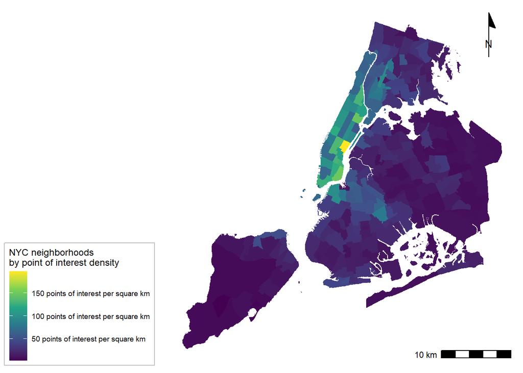

```r
nhoods <- nhoods %>%
  mutate(area = set_units(st_area(nhoods), km^2)) %>%
  mutate(poi_dens = as.numeric(num_poi / area))

ggplot(nhoods) +
  geom_sf(color = NA,
          aes(fill = poi_dens)) +
    scale_fill_viridis_c(name =
                           "NYC neighborhoods\nby point of interest density",
                       breaks = breaks <- seq(0, 200, by = 50),
                       labels = paste(prettyNum(breaks, big.mark = ","),
                                      "points of interest per square km")) +
  annotation_scale(location = "br") +
  annotation_north_arrow(location = "tr",
                         style = north_arrow_minimal()) +
theme_map() +
  theme(legend.position = "left",
    legend.background = element_rect(fill = alpha("white", 0.5),
                                         color = "gray"))
```

## Map 6: How far is each subway entrance from a point of interest?

```r
subway <- subway %>%
  mutate(poi_dist = st_nn(subway, poi,
                           returnDist = TRUE)$dist) %>%
  mutate(poi_dist = as.numeric(poi_dist))
```

```
## projected points
```

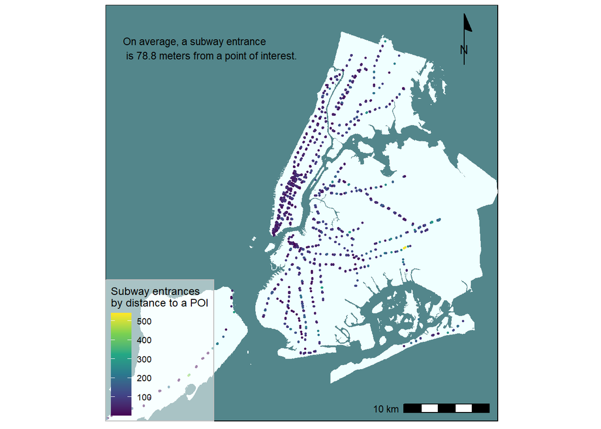

```r
avg_poi_dist <- mean(subway$poi_dist)

#This returns 78.79312. This means that each subway entrance is on average 79 meters away from a point of interest.

right_side <- st_bbox(subway)$xmax
left_side  <- st_bbox(subway)$xmin
top_side <- st_bbox(subway)$ymax
bottom_side <- st_bbox(subway)$ymin


ggplot(nhoods) +
  geom_sf(fill = "azure", color = NA) +
  geom_sf(data = subway, size = 0.5,
          aes(color = poi_dist)) +
  coord_sf(xlim = c(left_side + 2000, right_side + 2000),
           ylim = c(bottom_side + 2000, top_side + 2000), expand = TRUE) +
  scale_color_viridis_c(name =
                          "Subway entrances\nby distance to a POI") +
  annotation_scale(location = "br") +
  annotation_north_arrow(location = "tr",
                         style = north_arrow_minimal()) +
  annotate(geom = "text", x = left_side + 300,
           y = top_side - 800,
           label = paste("On average, a subway entrance\nis ",
                         prettyNum(avg_poi_dist, digits = 3),
                         " meters from a point of interest.",
                         sep = ""),
           hjust = -0.1, vjust = 0.5, size = 3) +
  theme_map() +
  theme(panel.background = element_rect(fill = "cadetblue4"),
        legend.background = element_rect(fill = alpha("white", 0.5),
                                         color = "gray"))
```